# **Predictive Modelling an YELP-Reviews**

# 6 Modellbildung

Im letzen Schritt wird das caret-Package verwendet, um ein Klassifikationsmodell zu erstellen, welches die Nützlichkeit eines Reviews aus den Daten vorhersagen soll.

Die Klassifikation funktioniert so, dass bereits codierte Daten (in unserem Beispiel: alle Daten wurden schon als nützlich oder nicht nützlich bewertet) zum trainieren eines Modells verwendet werden um ein Muster in den Variablen zu erkennen, durch welches die Klassifizierung noch nicht bekannter Daten ermöglicht werden soll. Näheres wurde bereits in `2 Projektziel` erläutert.

Um zwei Modelle vergleichen zu können wird ein randomForest-Modell und ein Multivariate-Adaptive-Regression-Splines-Modell verglichen.

## 6.1 Die Modelle

Ein [`random Forest`](https://de.wikipedia.org/wiki/Random_Forest) erstellt aus Teilmengen der Trainingsdaten Entscheidungsbäume, die jeweils gute Vorhersagen für diese Teilmengen treffen könne/sollen. Sollen neue Daten klassifiziert werden, gibt jeder Baum eine Entscheidung ab, in welche Kategorie die Observation fällt. Diese wird dann Anhand eines Mehrheitsvotings der einzelnen Bäume in eine der Kategorien eingeteilt.

Bei [`MARS`](https://en.wikipedia.org/wiki/Multivariate_adaptive_regression_splines) wird hingegen versucht eine Regressionslinie (aber keine Gerade) durch die Trainingsdaten zu legen, die Anhand der Prädiktoren die Daten in die zwei zu klassifizierenden Faktoren zerlegt. Ist eine neue Observation bei den Trainingsdaten in die Kategorie “nützlich” gefallen, werden diese ebenfalls als “nützlich” klassifiziert und umgekehrt.

Um die Modelle jedoch anwenden zu können, müssen die Daten noch entsprechend aufbereitet werden.

```r
#durch doParallel werden Verbindungen geöffnet, die beim Modelbuilding Fehler verursachen können
# unregister-Funktion schließt diese Verbindungen präventiv, auch wenn keine Vorhanden sein sollten
unregister <- function() {
  env <- foreach:::.foreachGlobals
  rm(list=ls(name=env), pos=env)
}

unregister()
```

## 6.2 Vorbereiten der Daten zur Modellbildung

Eine Darstellung der aktuellen Daten zeigt, dass noch 4 Faktoren im Modell enthalten sind - diese müssen vor Modellerstellung noch Dummykodiert werden.

```r
gc()
```

```
##            used  (Mb) gc trigger   (Mb)  max used   (Mb)
## Ncells 10021188 535.2   25102783 1340.7  25102783 1340.7
## Vcells 60933182 464.9  165468737 1262.5 708139294 5402.7
```

```r
# "Dateien/merged_phoenix.RData" wird benötigt

merged = merged_phoenix


## Trainings- (75% der Daten) und Testset (25% der Daten) erstellen
trainRowNumbers <- createDataPartition(merged$review_useful_rating, p = 0.75, list = F)
merged_train = merged[trainRowNumbers,]
merged_test = merged[-trainRowNumbers,]

#kurze entfernen des zu klassifizierenden Faktors, damit er nicht dummy-kodiert wird
x = select(merged_train, -review_useful_rating)
y = merged_train$review_useful_rating

# erstellt eine Zusammenfassung numerischer Variablen und zeigt NAs bei Faktoren, die dummycodiert werden müssen
skimmed <- skim_to_wide(merged_train)
skimmed[, c(1:5, 9:11, 13, 15:16)]
```

```
## # A tibble: 26 x 11
##    type   variable    missing complete n     mean  sd    p0    p50   p100
##    <chr>  <chr>       <chr>   <chr>    <chr> <chr> <chr> <chr> <chr> <chr>
##  1 factor restaurant~ 0       13956    13956 <NA>  <NA>  <NA>  <NA>  <NA>
##  2 factor review_sta~ 0       13956    13956 <NA>  <NA>  <NA>  <NA>  <NA>
##  3 factor review_use~ 0       13956    13956 <NA>  <NA>  <NA>  <NA>  <NA>
##  4 factor review_use~ 0       13956    13956 <NA>  <NA>  <NA>  <NA>  <NA>
##  5 integ~ restaurant~ 0       13956    13956 " 61~ " 40~ 100   680   1526
##  6 integ~ review_age~ 0       13956    13956 1156~ " 86~ 0     965   4640
##  7 integ~ review_wc_~ 0       13956    13956 "  5~ "  4~ 4     37    481
##  8 integ~ review_wc_~ 0       13956    13956 " 10~ "  9~ 5     71    941
##  9 integ~ user_compl~ 0       13956    13956 "   ~ "  2~ 0     0     1159
## 10 integ~ user_compl~ 0       13956    13956 "  9~ " 80~ 0     1     43259
## # ... with 16 more rows, and 1 more variable: hist <chr>
```

Im zweiten Schritt werden aus den im Modell enthaltenen Faktoren dummy-Variablen erstellt, da ein Klassifikationsmodell nur mit numerischen Variablen oder zweistufigen Faktoren arbeiten kann - mehrstufige Faktoren müssen deshalb Dummycodiert werden.

```r
#dummy-Kodierung der Trainingsdaten
dummies_model = dummyVars(review_useful_rating ~ ., data = merged_train)
trainData_mat = predict(dummies_model, newdata = merged_train)
trainData <- data.frame(trainData_mat)
trainData$review_useful_rating <- y #Klassifizierungsfaktor wird wieder eingefügt
glimpse(as.tbl(trainData))
```

```
## Observations: 13,956
## Variables: 32
## $ review_stars_rating.1    <dbl> 1, 1, 0, 0, 0, 0, 0, 0, 0, 0, 0, 0, 0...
## $ review_stars_rating.2    <dbl> 0, 0, 0, 0, 0, 0, 0, 0, 0, 0, 0, 0, 0...
## $ review_stars_rating.3    <dbl> 0, 0, 0, 0, 0, 0, 0, 0, 0, 0, 0, 0, 0...
## $ review_stars_rating.4    <dbl> 0, 0, 0, 0, 0, 0, 1, 0, 0, 0, 0, 0, 1...
## $ review_stars_rating.5    <dbl> 0, 0, 1, 1, 1, 1, 0, 1, 1, 1, 1, 1, 0...
## $ review_fk_grade_level    <dbl> 2.926537, 3.837675, 5.731026, 5.12400...
## $ review_fk_reading_ease   <dbl> 90.87409, 92.92914, 75.34731, 73.1686...
## $ review_polarity          <dbl> 0.01515152, 0.00000000, 0.09615385, 0...
## $ review_pos_wc            <dbl> 4, 2, 15, 1, 16, 1, 1, 5, 5, 7, 8, 10...
## $ review_neg_wc            <dbl> 3, 2, 0, 0, 1, 0, 0, 0, 0, 0, 1, 2, 3...
## $ review_wc_b_pp           <dbl> 66, 57, 156, 25, 139, 21, 21, 93, 47,...
## $ review_wc_a_pp           <dbl> 32, 28, 82, 12, 81, 9, 14, 43, 30, 18...
## $ review_ratio_emo         <dbl> 0.10606061, 0.07017544, 0.09615385, 0...
```

[output cut: 19 more lines]

Um vor der Modellbildung schon schätzen zu können, welche Prädiktoren potenziell den größten Effekt haben, können featurePlots verwendet werden. Das Prinzip dahinter lautet: Wenn die Prädiktoren nach der vorherzusagenden Variable gruppiert werden und sich Gruppenunterschiede zeigen, wird der Faktor im späteren Modell mit hoher Wahrscheinlichkeit wichtig sein. Die Feature-Plots visualisieren diesen Gruppenunterschied Anhand von Box-Plot-Diagrammen, beachtet aber im Gegensatz zu den Modellen keine Abhängigkeiten.

Zur Interpretation sind dabei große Mittelwertsunterschiede am besten geeignet. Auffallende Faktoren sind dabei Bewertungen, die 5 Sterne vergeben, die beiden Wortanzahl-Variablen, das Alter des Reviews, das Emotionswortverhältnis, da Jahre die ein User schon YELP verwendet, alle 3 Kompliment-Variablen, die Anzahl der Fans eines Users sowie die Anzahl aller nützlichen Kommentare eines Users.

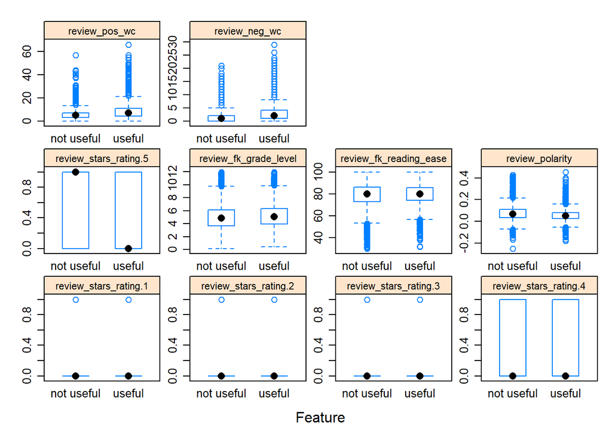

```r
#Um die Wichtigkeit der Variablen im vorhinein schätzen zu können, helfen featurePlots

x = featurePlot(x = trainData[, 1:10],
          y = trainData$review_useful_rating,
            plot = "box",
            strip = strip.custom(par.strip.text = list(cex=.7)),
            scales = list(x = list(relation = "free"),
                          y = list(relation = "free")))

y = featurePlot(x = trainData[, 11:20],
          y = trainData$review_useful_rating,
            plot = "box",
            strip = strip.custom(par.strip.text = list(cex=.7)),
            scales = list(x = list(relation = "free"),
                          y = list(relation = "free")))

z = featurePlot(x = trainData[, 21:30],
          y = trainData$review_useful_rating,
            plot = "box",
            strip = strip.custom(par.strip.text = list(cex=.7)),
            scales = list(x = list(relation = "free"),
                          y = list(relation = "free")))

x
```

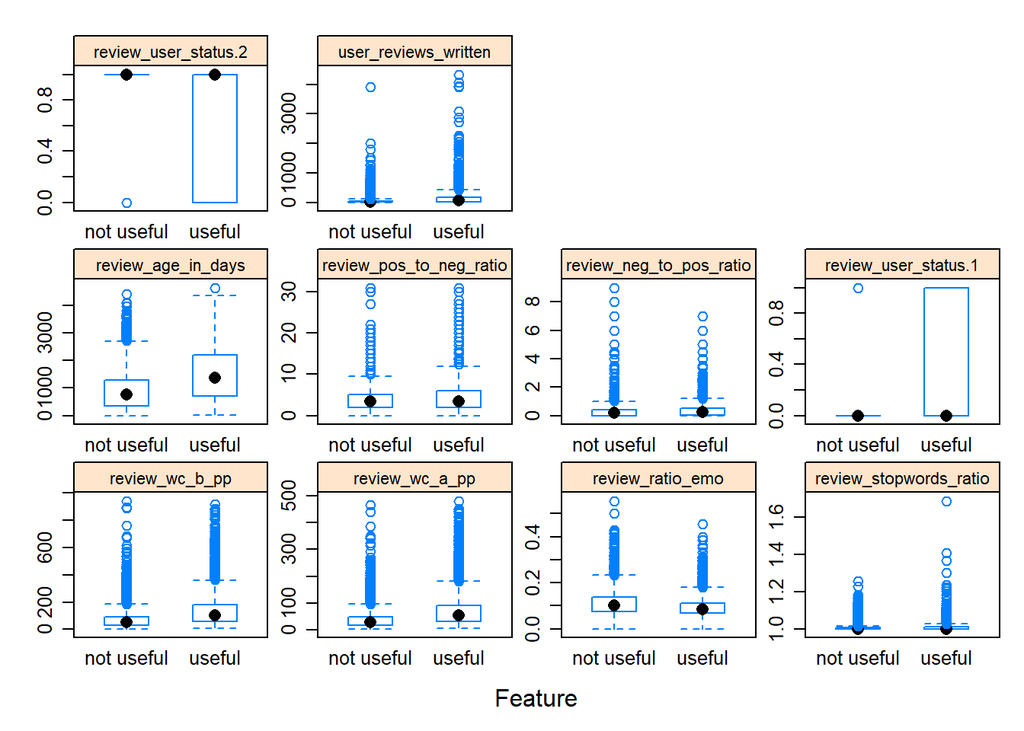

```r
y
```

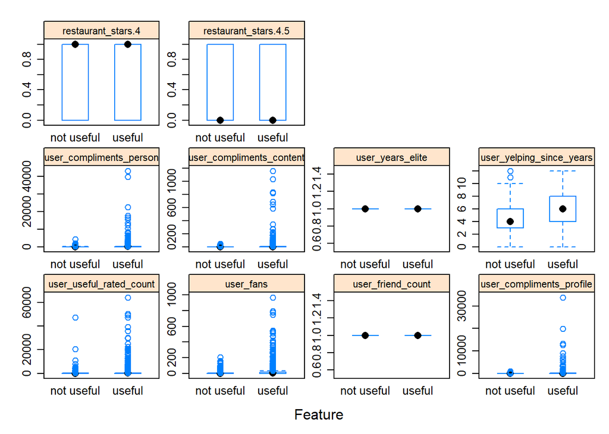

```r
z
```

## 6.3 Erstellen des RandomForest-Modells

In diesem Schritt wird das erste Modell erstellt. Es enthält standardmäßig 500 Klassifikationsbäume, die das Modell vorhersagen sollen und wird an 25 gebootstrapten Datensets crossvalidiert.

```r
### schauen, welche Variablen signifikant sind
set.seed(100)
options(warn = -1)

### Modell bauen
model_rf = train(review_useful_rating ~ ., data = trainData, method = "rf") #38 Minuten
save(x = model_rf, file = "Dateien/rfModel_merged.RData")

model_rf
```

```
## Random Forest
##
## 13956 samples
##    31 predictor
##     2 classes: 'not useful', 'useful'
##
## No pre-processing
## Resampling: Bootstrapped (25 reps)
## Summary of sample sizes: 13956, 13956, 13956, 13956, 13956, 13956, ...
## Resampling results across tuning parameters:
##
##   mtry  Accuracy   Kappa
##    2    0.7226555  0.4125569
##   16    0.7280354  0.4339094
##   31    0.7256035  0.4293713
##
## Accuracy was used to select the optimal model using the largest value.
## The final value used for the model was mtry = 16.
```

```r
testData_mat = predict(dummies_model, newdata = merged_test)
testData <- data.frame(testData_mat)
predicted_rf <- predict(model_rf, newdata = testData)


confusionMatrix(reference = merged_test$review_useful_rating, data = predicted_rf, mode = "everything")
```

```
## Confusion Matrix and Statistics
##
##             Reference
## Prediction   not useful useful
##   not useful       2160    754
##   useful            511   1226
##
##                Accuracy : 0.728
##                  95% CI : (0.715, 0.7408)
##     No Information Rate : 0.5743
##     P-Value [Acc > NIR] : < 2.2e-16
##
##                   Kappa : 0.4348
##  Mcnemar's Test P-Value : 1.017e-11
##
##             Sensitivity : 0.8087
##             Specificity : 0.6192
##          Pos Pred Value : 0.7412
##          Neg Pred Value : 0.7058
##               Precision : 0.7412
##                  Recall : 0.8087
##                      F1 : 0.7735
##              Prevalence : 0.5743
##          Detection Rate : 0.4644
##    Detection Prevalence : 0.6265
##       Balanced Accuracy : 0.7139
##
##        'Positive' Class : not useful
##
```

Das Modelgenauigkeitsdiagramm zeigt schön, dass bei einer zu großen Anzahl an Prädiktoren die Genauigkeit der Vorhersagen sinkt. Gründe dafür werden im Schlussteil diskutiert.

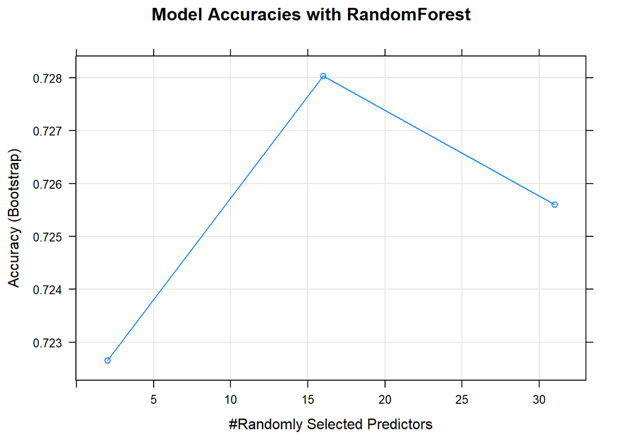

```r
plot(model_rf, main = "Model Accuracies with RandomForest")
```

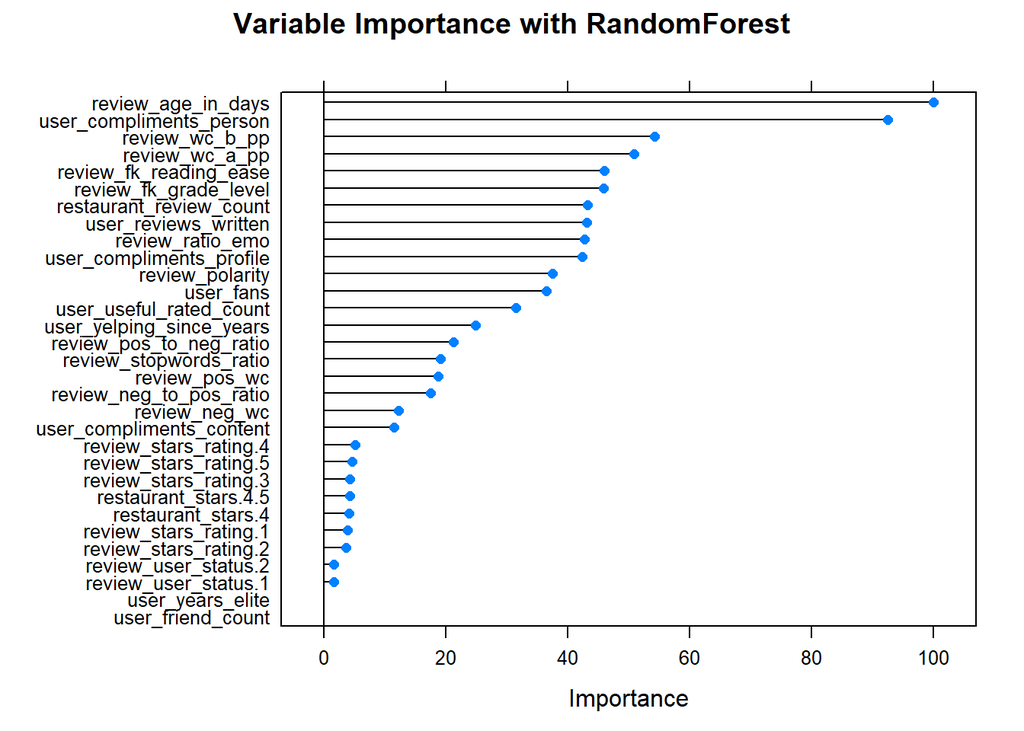

```r
varimp_rf = varImp(model_rf)
plot(varimp_rf, main = "Variable Importance with RandomForest")
```

## 6.4 Erstellen des MARS-Modells

```r
#2 Minuten
model_mars = train(review_useful_rating ~ ., data = trainData, method = "earth") #38 Minuten
save(x = model_mars, file = "Dateien/marsModel_merged.RData")

model_mars
```

```
## Multivariate Adaptive Regression Spline
##
## 13956 samples
##    31 predictor
##     2 classes: 'not useful', 'useful'
##
## No pre-processing
## Resampling: Bootstrapped (25 reps)
## Summary of sample sizes: 13956, 13956, 13956, 13956, 13956, 13956, ...
## Resampling results across tuning parameters:
##
##   nprune  Accuracy   Kappa
##    2      0.6863366  0.3238570
##    9      0.7237617  0.4203943
##   17      0.7262038  0.4259198
##
## Tuning parameter 'degree' was held constant at a value of 1
## Accuracy was used to select the optimal model using the largest value.
## The final values used for the model were nprune = 17 and degree = 1.
```

Ebenfalls wie das random Forest-Modell, funktioniert das MARS-Modell ähnlich gut, hier sogar leicht besser, an neuen Daten als am Trainingsdatenset, womit angenommen werden kann, dass für unsere Datengrundlage sich beide Modelle gut eignen, um die Nützlichkeit eines Reviews vorherzusagen.

```r
predicted_mars <- predict(model_mars, newdata = testData)

confusionMatrix(reference = merged_test$review_useful_rating, data = predicted_mars, mode = "everything")
```

```
## Confusion Matrix and Statistics
##
##             Reference
## Prediction   not useful useful
##   not useful       2251    846
##   useful            420   1134
##
##                Accuracy : 0.7278
##                  95% CI : (0.7148, 0.7406)
##     No Information Rate : 0.5743
##     P-Value [Acc > NIR] : < 2.2e-16
##
##                   Kappa : 0.4274
##  Mcnemar's Test P-Value : < 2.2e-16
##
##             Sensitivity : 0.8428
##             Specificity : 0.5727
##          Pos Pred Value : 0.7268
##          Neg Pred Value : 0.7297
##               Precision : 0.7268
##                  Recall : 0.8428
##                      F1 : 0.7805
##              Prevalence : 0.5743
##          Detection Rate : 0.4840
##    Detection Prevalence : 0.6659
##       Balanced Accuracy : 0.7077
##
##        'Positive' Class : not useful
##
```

Wie hier im Modelgenauigkeitsplot zu erkennen ist, steigt die Genaugkeit des Modells mit mehr Prädiktoren an, hier wurden jedoch nicht mehr als 17 Prädiktoren ins Modell mit aufgenommen, deshalb kann nicht gesagt werden, ob das Modell mit allen Prädiktoren noch besser wäre.

Was der Variablenwichtigkeitsplot jedoch auch in diesem Modell zeigt, ist, dass die aufbereiteten Metadaten der Sets, mit Ergänzung der Wortanzahl des Reviews ausreichend sind, um die Nützlichkeit von Reviews vorherzusagen. Fans der User gehen hier als wichtigster Prädiktor ins Modell ein.

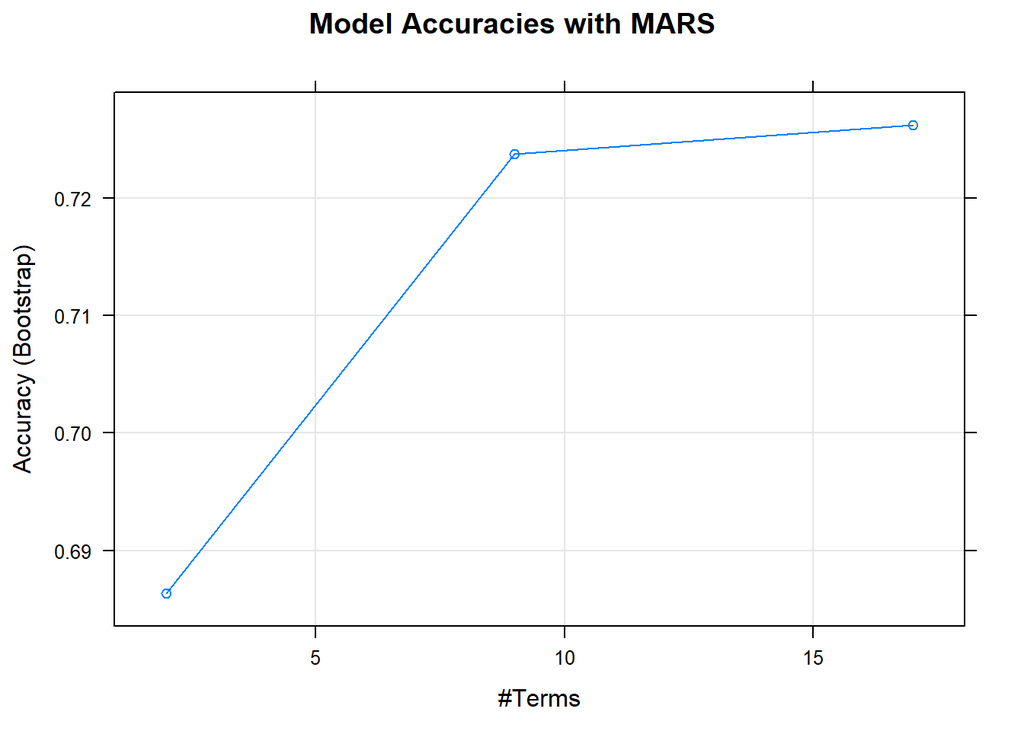

```r
plot(model_mars, main = "Model Accuracies with MARS")
```

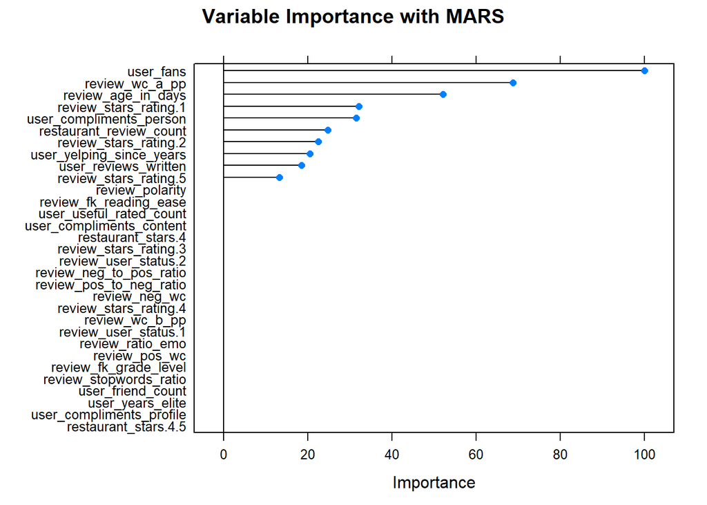

```r
varimp_mars = varImp(model_mars)
plot(varimp_mars, main = "Variable Importance with MARS")
```

```r
compare_models <- resamples(list(Mars_Model = model_mars, RandomForest_Model = model_rf))
summary(compare_models)
```

```
##
## Call:
## summary.resamples(object = compare_models)
##
## Models: Mars_Model, RandomForest_Model
## Number of resamples: 25
##
## Accuracy
##                         Min.   1st Qu.    Median      Mean   3rd Qu.
## Mars_Model         0.7157833 0.7222331 0.7260059 0.7262038 0.7294004
## RandomForest_Model 0.7207805 0.7250339 0.7268102 0.7280354 0.7316060
##                         Max. NA's
## Mars_Model         0.7397581    0
## RandomForest_Model 0.7377499    0
##
## Kappa
##                         Min.   1st Qu.    Median      Mean   3rd Qu.
## Mars_Model         0.4067577 0.4191621 0.4266929 0.4259198 0.4307536
## RandomForest_Model 0.4162578 0.4270069 0.4321222 0.4339094 0.4420763
##                         Max. NA's
## Mars_Model         0.4539109    0
## RandomForest_Model 0.4556490    0
```

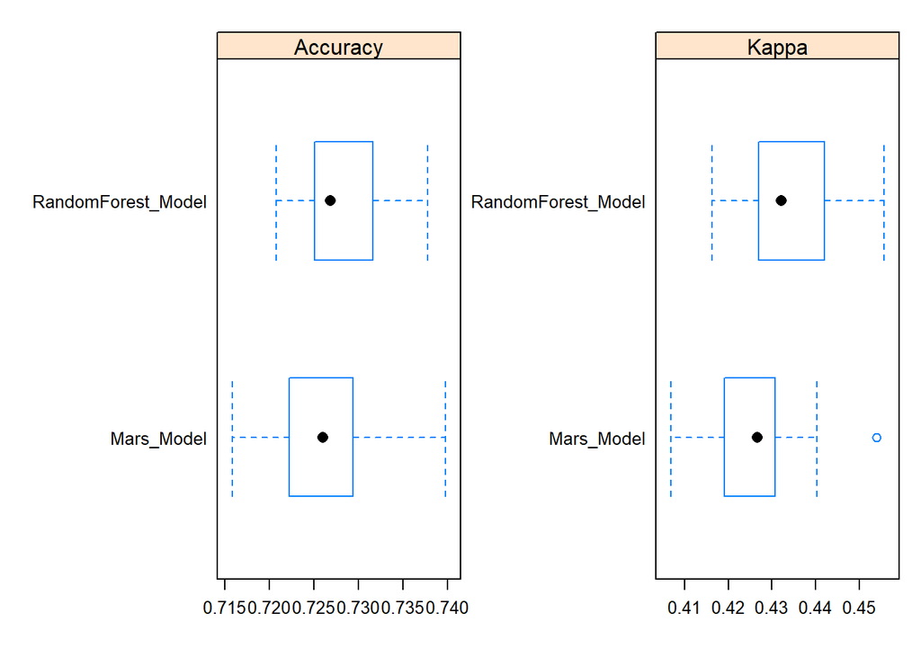

```r
scales <- list(x = list(relation = "free"), y = list(relation = "free"))
bwplot(compare_models, scales = scales)
```

```r
mergedNames <- names(trainData)
X <- as.vector(mergedNames[-31])
form <- as.formula(paste("review_useful_rating","~", paste(X, collapse="+")))
tree = rxDTree(form, data = trainData)

jpeg("DecisionTree1.jpg", width = 6000, height = 2000, res = 999)
rpart.plot::prp(rxAddInheritance(tree))
dev.off()
jpeg("DecisionTree2.jpg", width = 8000, height = 2400, res = 999)
fancyRpartPlot(rxAddInheritance(tree))
dev.off()
```

# 7 Resümee

Die genaue Fragestellung lautete, ob es möglich ist mit Hilfe aus den Ursprungsdaten gewonnener Variablen ein Klassifikationsmodell zu erstellen, dass mit einer Wahrscheinlichkeit deutlich über der “No-Information-Rate” (“Rateniveau”) vorhersagen kann, ob andere Nutzer ein Review als nützlich bewerten werden oder nicht.

Es bleibt jedoch der bittere Nachgeschmack, da alle aus den Reviews selbst gezogenen Daten, wie Polarität, Flesch-Kincaid-Werte und ähnliches keinen wirklichen Einfluss im Modell ausgeübt haben. Eine Erklärung dafür könnte sein, dass verschiedene User auf verschiedene Komplexität und Polairtät in Revies Wert legen und es zum Teil einfach Zufall ist, ob Bewertungen, die objektiv gesehen nützlich wären, auch so bewertet werden wurden bzw. ob Reviews, die objektiv gesehen keinen Nutzen besitzen von mindestens einen User eine solche Bewertung erhalten hat. Diese Idee wird auch dadurch verstärkt, dass, abgesehen von der Wortanzahl des Reviews, hauptsächlich die Zeit und die Fans von Usern ausschlaggebende Prädiktoren waren. Hat ein User Fans werden diese seine Reviews schneller als nützlich bewerten, unabhängig davon ob es diese auch objektiv sind. Gibt es ein Kommentar schon lange, hat zumindest ein User dieses im Verlauf von mehreren Jahren vielleicht einmal als nützlich bewertet.

Um ein genaueres Ergebnis zu erhalten könnten für kommende Projekte 2 Dinge ausprobiert werden und zwar nur aus vorhandenen Daten am gleichen Datensatz ein Klassifikationsmodell zu erstellen und die Güte mit den hier erstellten Modellen zu vergleichen, oder alle Bewertungen händisch als “objektiv” nützlich oder nicht nützlich zu bewerten, um einen Faktor zu erhalten, der nützliche Reviews wirklich von nicht nützlichen unterscheide um daraus ein Modell zu bilden. Dies wäre natürlich sehr aufwendig, da alleine für dieses Datenset über 18 000 Daten händisch codiert werden müssten.

Abschließend kann jedoch gesagt werden, dass das Projekt ein zufriedenstellendes Ergebnis gezeigt hat, auch wenn das Ergebnis nicht meinen Erwartungen entsprochen hat.